# Kaggle_Comp_Manzella (1)

## Kaggle Prediction Competition: Duke CS671 FASHION-MNIST

### Kieran Manzella, Spring 2019

### 1. Exploratory Analysis:

Exploratory Analysis: images are difficult subjects to explore with scatterplots or covariance diagrams. The relationships that exist among data in this set is better explored with some reduction in dimensionality, but not down to 2D. To approach this, I am using a popular tool in dimensionality reduction: Principal Component Analysis (PCA). Before I get into that, let's load up some of the libraries that we'll be using throughout the project, and take a look at what we're dealing with.

```python
import numpy as np
from numpy import linalg
import pandas as pd
from random import randint
import matplotlib.pyplot as plt
import pdb
import math
import skimage
from skimage import feature
```

```python
images, labels = np.load("train_images.npy"), np.load("train_labels.npy")
test_images = np.load("test_images.npy")
```

```python
# I'm adding the labels to a version of the training data in order
# to extract class-specific data for exploratory analysis.
a = pd.DataFrame(images)
b = pd.DataFrame(labels).rename(columns={0:'labels'})
c = pd.concat((a,b,),axis=1)
```

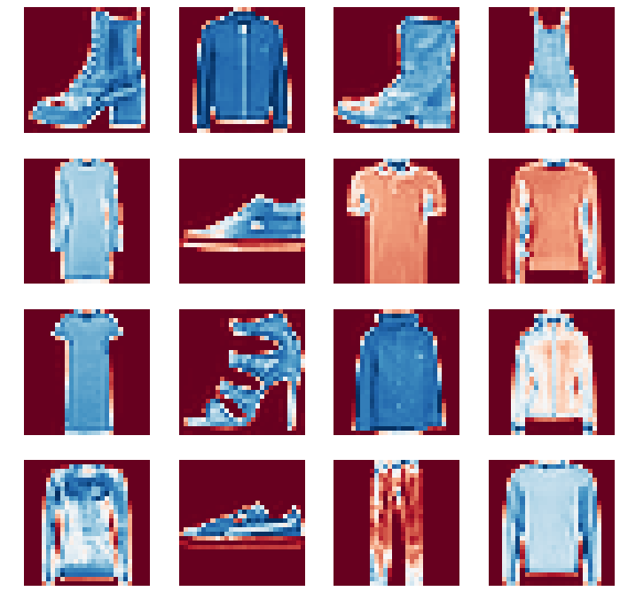

```python
# here, I display a 4x4 grid of 16 random draws from the input data
# which I reshape into a (28,28) grid that can be plotted by pyplot.
fig2 = plt.figure(figsize = (12,12))
cols = 4
rows = 4
for i in range(1,17):
    fig2.add_subplot(rows,cols,i)
    #selecting random images, declaring the color map to be red/blue
    plt.imshow(images[randint(0,np.shape(images)[0])].reshape((28,28)),cmap= 'RdBu')
    # no need for titles or axes
    plt.axis('off')
plt.show(fig2)
```

Using that reference, let's look at the average pixel values for each class, and figure out a bit more of what we're dealing with. Following the images of class average, cumulative histograms of their pixel values are shown.

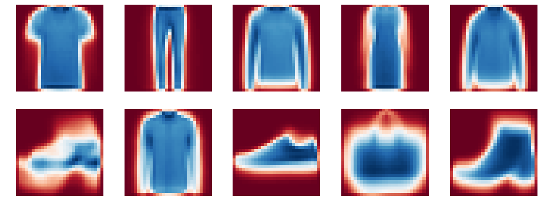

```python
averages = []

# using the above data+labels dataframe, I select input data for
# individual classes, one by one, and then calculate their averages,
# and append those averages to a dataframe declared above.
for i in range(0,10):
    indices1 = np.where(c['labels']==i)
    ims1 = a
    selection1 = ims1.iloc[indices1].values
    selection_avg = np.mean(selection1, axis = 0)
    averages.append(selection_avg)

# plot 10 grids for 10 classes, each with the average pixel value
# calculated for that particular class, reshaped from 784 to a
# (28,28) grid that can be plotted with pyplot.
fig1=plt.figure(figsize=(16,6))
columns = 5
rows = 2
for i in range(1,11):
    fig1.add_subplot(rows, columns, i)
    plt.imshow(averages[i-1].reshape((28,28)),cmap='RdBu')
    plt.axis('off')
plt.show()
```

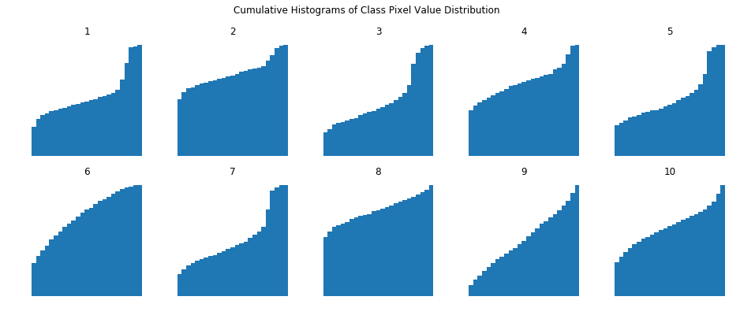

```python
average_distribution = []
fig1=plt.figure(figsize=(16,6))
columns = 5
rows = 2
for i in range(1,11):
    fig1.add_subplot(rows, columns, i)
    plt.hist(np.ravel(averages[i-1]), bins = 25, cumulative = True)
    plt.axis('off')
    plt.title(i)
    plt.suptitle("Cumulative Histograms of Class Pixel Value Distribution")
plt.show()
```

The classes within FASHION_MNIST are:

1. T-shirt
2. Pants
3. Pull-over shirt
4. Dress
5. Coat
6. Sandal
7. Shirt
8. Sneaker
9. Bag
10. Boot

From the above display, we can see how simple averages may cause confusion among classes, particularly the three classes with long sleeves. In the histogram display of cumulative brigtness distributions, there are a few repeating patterns, enough at least to know that differentiating class by brightness distribution won't work for the whole set. The next section may help exploratory differentiation of classes.

Principal Component Analysis (PCA) is a way of reducing the dimensionality of rich data. The sample covariance of each feature of a data point $\{X\}^n_{i=1}\in \mathbb{R}^{784}$ is not very informative. To condense covariance information, the PCA approach uses partial implementation of singular value decomposition (SVD) applied to all $\{X\}^n_{i=1}$. To clarify partial implementation: in the case of a full SVD, the factorization of a matrix $A,\ dim(n\times m)$ contains a central element $\Sigma$, a square matrix with dimension $min(n,m)^2$ containing all eigenvalues of the product matrix $AA^T$ or $A^TA$ along its diagonal, and zeros elsewhere (the eigenvalues of both are identical).

$$\Sigma_{i,j} = (\lambda_i)\mathbb{1}_{[i = j]}$$

For PCA, A is normalized, but it's important to note that $A^TA$ and $AA^T$ will both be positive semi-definite matricies; negative eigenvalues would not work well in image processing. Whether or not $A$ is full-rank is not relevant to us, as the partial implementation limits the number of eigenvalues in the PCA output to a number $k$ of principal components we want to measure. In the case of $k = 16$ or $k = 4$, both of which I will use in a moment, there is no concern that the input data has fewer than 16 linearly independent features. To summarize the intuition behind this method, the PCA output of a dataset is the eigendecomposition of the data's covariance matrix, and for the parameter $k$, we will see the first $k$ most important features within the data, as sorted by magnitude of the eigenvector within the eigendecomposition.

To explore that structure, we can look at both the entirety of the dataset, and the dataset split into groups by label. I begin by implementing a simple PCA function with arguments (A, k) that take the input data matrix and the depth of decomposition desired. I then run that function with inputs (A = training images, k = 16), and display the first 16 elements of the eigendecomposition. All code in this section is my original work.

```python
def pca(A, k): # defines the eigendecomposition function of
               # SVD for a given dataframe and number of
               # singular values desired
    m,n = A.shape
    mu=np.mean(A, axis=0)
    # normalize input matrix
    A_center = A - mu
    # multiply normalized matrix by its transpose
    AtA = np.matmul(A_center.T,A_center)
    # calculate singular values of the normalized matrix times transpose
    w,v = np.linalg.eigh(AtA)
    # singular values are given least-greatest;
    # we need to flip their order
    V = np.flip(v, axis=1)[:,0:k]
    # S and mu aren't necessary, but it would be strange to implement
    # this function without outputting a full SVD
    s = np.sqrt(w/(m-1))
    return mu, V, s
```

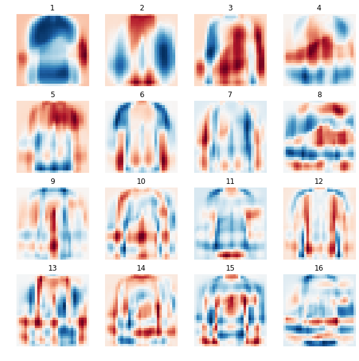

```python
# perform SVD on the full input data,
# for k = 16 singular values in 784 dimensions
_,PCA,_ = pca(images,16)
# initialize dataframe to hold individual singular value outputs
pca_images = []
for i in range(0,np.shape(PCA)[1]):
    # reshape k singular value vectors into original image dimension,
    # then add to dataframe for display
    pca_images.append(PCA[:,i].reshape(28,28))

# plot figures of the first 16 singular values:
fig=plt.figure(figsize=(10,10))
columns = 4
rows = 4
for i in range(1, 17):
    fig.add_subplot(rows, columns, i)
    plt.imshow(pca_images[i-1],cmap='RdBu')
    plt.title(i)
    plt.axis('off')
plt.show()
```

To expand on the intuition: given a large enough $k$, each image within the input dataset can be reconstructed to a reasonably high degree of detail as a linear combination of these components. As we see above, the gradients in the first 16 components allow for a diverse presentation of features and patterns, which is unsurprising, because the image features within FASHION_MNIST are not very similar across classes.

That reconstructability will become more clear as I split the data into groups based on their label, run PCA on each subset individually, and display the first 4 components of each class.

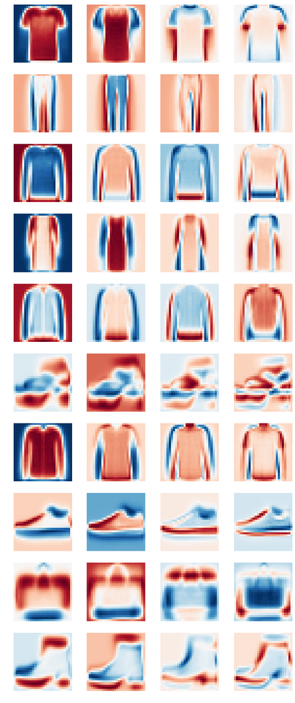

```python
pca_class = []

for i in range(0,10):
    # split up data into separate arrays based on their label
    indices = np.where(c['labels']==i)
    ims = a
    selection = ims.iloc[indices].values
    # perform singular value decomposition to extract first 4
    # characteristics of maximum variance
    _,sigmas,_ = pca(selection,4)
    for j in range(0,np.shape(sigmas)[1]):
        pca_class.append(sigmas[:,j].reshape(28,28))

# plot figures with 10 rows for the 10 classes, and 4 columns for the
# first 4 singular value decompositions
fig=plt.figure(figsize=(10,25))
columns = 4
rows = 10

for i in range(1, 41):
    # iterate through plot values to place the class-PCA output
    fig.add_subplot(rows, columns, i)
    plt.imshow(pca_class[i-1],cmap='RdBu')
    plt.axis('off')
plt.show()
```

As we can see above, the covariant components of individual classes are much more obvious representations of the underlying data. The aforementioned bit of intuition in reconstructability holds more clearly here; for example, each image within the class "handbag" could be reproduced with a high degree of accuracy as a linear combination of given components pca(A = images['handbags'], k), given large enough $k$.

Illustration of covariance from PCA informs exploratory analysis in two ways. First, we see that PCA run on classes within our training data finds powerful features in eigendecomposition, thus we know that the image arrays are highly covariant within classes- this is a good sign for any classification problem. Second, in determining an approach to the classification model, well-defined PCA ouput implies that methods outside of deep neural nets may be effective.

## 2. Models

The two approaches I will be taking to this dataset are a Support Vector Machine (SVM) and Convolutional Neural Net (CNN).

### 2.1 SVM

SVMs are a classic machine-learning approach to classification problems, and can be used in image classification by training on a feature vector that is more high-level than the raw pixel values of an image. The features that I will be using for the SVM model are Histograms of Oriented Gradients (HOGs). A HOG feature vector describes the topographical features of an image: edge location, the angles which describe the edges, and the magnitude of change orthogonal to the edges. The "gradients" element refers to the gradient of pixel brightness for a given point on the image, "oriented" refers to the angle of gradient at that point, and "histograms" are how the oriented gradients are described for a small part or block of the image. A HOG vector thus contains extremely informative features that can be used for object recognition; Dalal and Triggs (2005) used HOG vectors as input to an SVM for detecting humans in images. I will do the feature extraction myself, and use the scikit-learn library for SVM training. Sklearn's SVC kit provides a pretty user-friendly environment for multi-class differentiation, with parameter specification that is easy to tune. The process of creating and training a model can be done in two lines; the library contains all of the math underneath. All credit for the sklearn backend to the authors; citation: Scikit-learn: Machine Learning in Python, Pedregosa et al., JMLR 12, pp. 2825-2830, 2011. {https://scikit-learn.org}

### 2.1. CNN

CNNs are generally considered the most powerful tool for simple image classification problems. By performing "convolutions" on input images, they generate internal feature vectors of different image elements, and then learn which features combine to what label. While classic deep learning models like multi-layer perceptron can perform relatively well on basic classification problems by learning features from a single layer input, multi-layer input is intuitively a far superior approach to the problem. A CNN will learn what combinations of patterns best represent different classes, similarly to how humans subconsciously recognize objects as constructions of individual features. What differentiates a sandal from a boot? Straps, open areas throughout the construction, lower profile, etc.; the high-level features in an image representation can be learned and recognized through CNNs. For this section, I will use the keras library with tensorflow. In addition to being a powerfully adaptable library environment, keras/pytorch can wrangle my machine into using most of its CPU to train the model. Keras is a fairly high-level library, and I think it's worth some thought on several counts. The user-friendlyness of Keras has significantly lowered the technical ability necessary to solve problems with neural nets. Beyond offering a plug-and-play format for constructing net architecture, keras has available for public use the VGG pre-trained convolutional net, which is an extremely high-performing base for image classifcation. I won't be using that for this competition, as I believe it would be unfair, but it offers off-the-shelf performance of around 97% on Fashion-MNISt; I'm always interested by open-source technology allowing for cutting-edge performance. All credit for the keras backend to the authors; citation: Keras, François Chollet et al., 2015, {https://keras.io}

## 3. Training

### 3.1 SVM with HOG

The first step is to create the feature vectors that I will feed to the SVM model for training. Each image is processed by my gradient function, with which I then calculate the HOG descriptor for each image. Our input images are all 28 by 28 pixels, and so a good window for the HOG cell is 4, giving us 7 rows of 7 windows.

The gradient function takes an input image and produces two output arrays corresponding to the gradient angle and magnitude at each pixel in the input image. These are calculated by comparing the arrays of $\frac{\partial x}{\partial I}, \frac{\partial y}{\partial I}$, the point value change in image brigtness in the x and y directions. The paired values are fed into an arctan function and a 2D vector norm function to produce the angle and magnitude of change at each pixel. The image feature function splits the gradient function outputs into non-overlapping cells of 4x4, and feeds those 2D slices to the cell feature function.

The cell feature function flattens the arrays into two 1-dimensional arrays of 16 values. That information is used to assign votes to each bin through bilinear interpolation (a input pair with angle value 60 and magnitude 1 will contribute equal votes of 0.5 to bins 2 and 3, corresponding to angle intervals [40, 60] and [60, 80]). Instead of being grouped in counts, the way we are used to seeing data for histograms, the votes are simply added to each other to produce a 1-dimensional vector with 9 elements. Cells are grouped into blocks, with some overlap, and the blocks are normalized.

All code in this section is my original work, but the theoretical method is from Dalal and Triggs (2005), and much of the mathematical technique (angle magnitude and direction, bilinear voting) is inspired by a summary of the original HOG paper by Professor Carlo Tomasi. I brought in the skimage library later to help streamline the process, credit for the skimage backend to the authors; citation: Stéfan van der Walt, Johannes L. Schönberger, Juan Nunez-Iglesias, François Boulogne, Joshua D. Warner, Neil Yager, Emmanuelle Gouillart, Tony Yu and the scikit-image contributors. scikit-image: Image processing in Python. PeerJ 2:e453 (2014) https://doi.org/10.7717/peerj.453

```python
# Calculate the gradient of an image:

def gradient(image): # output two arrays with size equal to input, one with the
                     # magnitude of change in brigtness in 2 dimensions for a given
                     # pixel of the input, and one with the angle of maximum change
                     # at that pixel

    # initialize dimensions, make sure data is the right type
    m,n = np.shape(image)
    image = np.ndarray.astype(image, dtype = 'float')
    # intialize arrays for the horizontal gradient, vertical gradient,
    # and output arrays
    res_x = np.zeros([m,n])
    res_y = np.zeros([m,n])
    angle = np.zeros([m,n])
    magnitude = np.zeros([m,n])

    for i in range(1,m-1):
        for j in range(1,n-1):
            # for each point in the image, calculate simple plus-one, minus-one
            # changes in pixel brigtness based on change in x or change in y
            res_x[i,j] = (image[i,j-1] - image[i,j+1])
            res_y[i,j] = (image[i-1,j] - image[i+1,j])
            # calculate angle of maximum gradient with arctan fucntion used over the
            # x and y values produced above
            angle[i,j] = abs(np.rad2deg(math.atan2(res_y[i,j],res_x[i,j])))
            # calculate magnitude by the value of the euclidean norm of the x and y
            # values produced above
            magnitude[i,j] = np.sqrt(res_x[i,j]**2 + res_y[i,j]**2)

    return angle, magnitude


def HOG_cell_feature(im_angles, im_magnitude, bins): # create a histogram of weighted
                                                     # votes for binned angles for
                                                     # an input cell

    # declare number of bins for angle votes, and the resultant width of the bins
    B = bins
    w = 180/bins
    m,n = np.shape(im_angles)
    res = np.zeros(shape = (bins))

    #for a given cell, reshape the grid into 1-dimensional arrays of values
    angles = np.ravel(im_angles)
    mags = np.ravel(im_magnitude)

    # iterate over values in the cell: use bilinear voting to assign a weighted
    # vote to bins. bins are chosen and votes are allocated by method described above.
    for i in range(0,m*n-1):
        j = max(0,int((np.floor(angles[i]/(w) - 0.5))%B))
        vote_1 = mags[i]*(((w*(j+1.5)) - angles[i])/w)
        vote_2 = mags[i]*((angles[i] - w*(j+0.5))/w)
        res[j-1] = res[j] + vote_1
        res[j] = res[j] + vote_2
    return res

def HOG_image_feature(image,cell_size=4):
    m,n = np.shape(image)
    orientations, magnitudes = gradient(image)
    features = []
    for i in range(0,m-1,cell_size):
        for j in range(0,n-1,cell_size):
            im_angles = orientations[i:i+cell_size,j:j+cell_size]
            im_mags = magnitudes[i:i+cell_size,j:j+cell_size]
            features.append(HOG_cell_feature(im_angles,im_mags,9))
    return features
```

```python
from skimage.feature import hog
# intialize output array
sk_HOG_features = []
sk_HOG_features_test = []

# do everything I did above in the functions above, but with a pre-built library
for i in range(0, len(images)):
    pic = np.ndarray.astype(images[i], dtype = 'float').reshape(28,28)
    features,_ = skimage.feature.hog(pic, visualize=True, feature_vector = True)
    sk_HOG_features.append(features)
for i in range(0, len(test_images)):
    pic =np.ndarray.astype(test_images[i], dtype = 'float').reshape(28,28)
    features,_ = skimage.feature.hog(pic, visualize=True, feature_vector = True)
    sk_HOG_features_test.append(features)
sk_HOG_features = np.array(sk_HOG_features)
sk_HOG_features_test = np.array(sk_HOG_features_test)
np.save("HOG_features_train.npy",sk_HOG_features)
np.save("HOG_features_test.npy",sk_HOG_features_test)
```

```
C:\ProgramData\Anaconda3\lib\site-packages\skimage\feature\_hog.py:150: skimage_deprecation: Default value of `block_norm`==`L1` is deprecated and will be changed to `L2-Hys` in v0.15. To supress this message specify explicitly the normalization method.
  skimage_deprecation)
```

```python
# Uncomment following block to use self-made HOG feature generator

# homemade_HOG_features = []
# for image in images:
#     im = images[i].reshape((28,28))
#     homemade_HOG_features.append(np.ravel(HOG_image_feature(im, cell_size = 4)))
```

### 3.1 SVM Training

*As training and CV for hyperparameter selection happen simultaneously, all code will be in section 4*

The previous section doesn't address the actual model training, so here's a brief description of what the SVM is doing. The model takes in data in as many dimensions as are given to it by the HOG descriptor. Under the hood, the model is trying to find the optimum for a particular function:

$\min\limits_{w, w_0} ||w||^2_2 \ \ \mathbf{s.t.} -(y_i(w^tx_i + w_0)) \leq 0 \ \forall i = 0,1...n$

The optimum solution is the minimum-norm weight vector that satisifies correct classification for each data point $\{X_i,Y_i\}_{i=1}^n$. However, in an image classification problem, it's unlike that we will have completely separable data. The function above has a lagrangian formulation that leads to it's quadratic programming problem, but I'll skip to the lagrangian of the non-separable case that we are dealing with.

$\mathcal{L}(w, w_0, \xi, \alpha, r) = \frac{1}{2}||w||^2_2 +C\sum\limits_{i=1}^n \xi_i - \sum\limits_{i=1}^n \alpha_i[y_i(w^Tx_i + w_0) - 1 + \xi_i] - \sum\limits_{i=1}^n r_i\xi$

For all that's going on here, what really matters are the relationships of the variables $\xi$ in the sums. Because the data isn't separable, there is slack allowed in the product of the target and classified value ($y_i(w^Tx_i + w_0)$), designated $\xi$, but this adds cost to the objective function; this comes from the primal condition $y_i(w^Tx_i + w_0) \geq 1-\xi_i$- C is the measure for how much that slack costs. The dual problem, which is optimized by the model, is a translation of the lagrangian through KKT into something that can be solved by quadratic programming:

$$\max\limits_{\alpha} \sum\limits_{i=1}^{n} \alpha + \sum\limits_{i,j=1}^{n} \alpha_i \alpha_j y_i y_j \mathbf{x}_i^T \mathbf{x}_j \ \ \ \mathbf{s.t.}: \{ 0 \leq \alpha_i \leq C \ \forall i = 1...n\ \ \& \sum\limits_{i=1}^{n} \alpha_i y_i = 0 \} $$

The element $\mathbf{x}_i^T\mathbf{x}_j$ is where the kernels that I will be using as different hyperparameters come in; through the representer theorem, SVM can solve this optimization problem for any valid kernel on $\mathbf{x}_i,\mathbf{x}_j$, and I will be testing several.

The time necessary to train the model varies based on kernel and penalty parameters. A polynomial kernel might not take an extremely long time to compute, but mapping data into higher dimensions increases the complexity of determining support vectors and fitting margins. The penalty adds computational complexity as well; by changing costs for slack and support vector selection, the optimization problem becomes simpler or more complex, and the runtime changes drastically. During cross-validation, training a linear kernel with penalty C = 1 took about 15 minutes, but training a gaussian kernel with penalty C = 1000 took a few hours.

### 3.2 CNN Training

The convolutional neural network is trained like any multi-layer network, wherein the loss $\mathbf{L}$ is some function on the difference between the target value and predicted value for a pair in $\{X_i,Y_i\}_{i=1}^n$. The gradient of the loss is calculated for each weight leading into the output layer, and those gradients are used layer-by-layer to estimate $\nabla_{w^k_{i,j}}\mathbf{L} \ \forall \ i,j,k \in \mathbf{M}$, the gradient of loss with respect to every connecting weight in the structure: M is the full model, consisting of layers $k$, nodes $j$ in layer $k$, and nodes i in layer $(k-1)$. The structure of layers, particularly the first few following the input layer, is what differentiates this model from a basic neural network. The term "convolution" is more commonly heard in computer vision, wherein an image kernel is convolved over different windows of the image to extract features and patterns; Image kernels are very different from kernels used in SVM, for the record. For example, two image kernels are the truncated gaussian, and the derivative of the gaussian; by convolving an image with these kernels, one can blur (apply gaussian normalization to pixel values within the window to be convolved) or transform the image to it's brightness gradient in one dimension (apply the derivative of the gaussian to calculate $\frac{\partial I}{\partial x,y}$) over the image. In CNNs, simple kernels are used to extract features in terms of patterns occuring in different places in the image. The input data, as a set of pixels, is passed through multiple filters that slowly scale in size. Small filters near the beginning of the net capture shapes and gradients of small parts of the image, and then those filter outputs are put through larger filters, slowly scaling up to capture the entire convolved input.

That structure is meant to help CNNs perform object recognition in an organic way; as we as humans recognize large and complex objects as a combination of smaller and simpler features. A face is a combination of features in eyes, noses, mouths, etc., but a face can be recognized by a few lines and shaded shapes; the underlying patterns in visual gradient are the small features we learn that get cognitively recombined into a larger pattern.

That's the reasoning behind the CNN structure, and its training is much like other neural networks; it uses cross-entropy as its loss function. Cross entropy calculates loss as how wrong the network was in its prediction. With multi-class problems, the network's guess is the label with the greatest softmax value as output- if the label has 10 classes that correspond to 10 output nodes, and the network assigns highest probability to the correct node, there is relatively little loss, but the network can still learn. The "correct" values of the output nodes are 1.00 for the target value, and 0.00 for everything else. The differences between these correct values and the softmax values of the network can be used for training on every iteration, even the passes where the network guesses correctly. Cross-entropy loss is piecewise-differentiable, so the negative gradient of the loss can be back-propagated through the network to tune the weight vectors.

The optimizer that I end up choosing is AdamOptimizer, the keras implementation of Adam. Adam differs from SGD slightly, and combines the best elements of RMSprop and Adagrad. It incorporates a few parameters more than SGD, which allow for adaptive momentum (speed of descent) and control for optimal performance by using higher level moments of estimators than simple SGD

Throughout the training process, I'm using single-fold CV, more on that later. One added benefit of structuring the training process with this option is tracking the test and validation loss and accuracy metrics across epochs. Throughout training, the time necessary to fit the models with the parameters I am providing has been hanging around 30 minutes. The individual epochs took between 190 and 230 seconds each, and I used 10 epochs on each model configuration.

## 4. Hyperparameter Selection

### 4.1 SVM Hyperparameter Selection

In this section, I will be fitting an SVM to the input data of HOG vectors with several different functions, iterating over different SVM kernels and penalty values. I am running 16 training iterations with all combinations of 4 kernel options and 4 penalty options: kernel = ["linear","poly","rbf","sigmoid"], penalty = [1,10,100,1000]. Within each combination, I use nested cross validation (Stratified_KFolds) with a indexer from sklearn. No-Free-Lunch says that there's no way to predict which kernel will perform best, so I'm brute forcing it.

After each iteration of model training, I make predictions on the validation set. At the end of the nested cross-validation, I compute the mean accuracy and f1 scores across training and validation sets for the kernel and penalty combination. With those reports, I can select which model fits the data best, and make predictions on the competition test data. This follows the structure of nested k-folds CV with one designated set for testing- that set is the Kaggle test data in this case.

In this case, the hyperparameters that fit the data best are the linear, gaussian, and sigmoid kernels with high penalty (C = 1000), all performing at an average around ~82% on the validation sets.

```python
from sklearn.svm import SVC
from sklearn.model_selection import train_test_split
from sklearn.model_selection import StratifiedKFold
from sklearn.metrics import classification_report, confusion_matrix, accuracy_score, f1_score
```

```python
def cross_val_SVM(): # I'm using a function to do all of this so
                     # I won't mess with global variables

    # intialize output array to store accuracy, array for kernel values,
    # and array for penalty values
    res = []
    kernels = ["linear","poly","rbf","sigmoid"]
    C = [1,10,100,1000]

    for kernel in kernels:
        for penalty in C:
            # initialize arrays to store accuracy and f1 scores of multi-fold validation
            accuracy = []
            f1_scores = []
            # declare model and parameters on iterable hyperparameters
            svclassifier = SVC(C = penalty, kernel = kernel)
            # split training data into stratified folds, to optimize multi-class training
            # and stop overlap of training data and validation data
            strat_k_folds = StratifiedKFold(n_splits = 5)
            for train_index, test_index in strat_k_folds.split(sk_HOG_features,labels):
                # select data based on split indices created above
                x_train = sk_HOG_features[train_index]
                y_train = labels[train_index]
                x_val = sk_HOG_features[test_index]
                y_val = labels[test_index]
                # train model on selected fold, test model on validation fold
                svclassifier.fit(x_train,y_train)
                y_pred = svclassifier.predict(x_val)

                # create and append accuracy and f1 scores to outer arrays
                acc = accuracy_score(y_val,y_pred, normalize = True)
                f1 = f1_score(y_val,y_pred, average = 'weighted')

                accuracy.append(acc)
                f1_scores.append(f1)
            # append the mean accuracy and f1 scores for the k-folds cross-validation
            # iteration with the given kernel and penalty parameters
            res.append([kernel,penalty,np.mean(accuracy),np.mean(f1_scores)])
            print('success',kernel,penalty)

    return res
```

```python
# Don't run this block unless you have 10 hours

# SVM_TEST_2 = cross_val_SVM()
```

```python
np.save("SVM_TEST_RESULTS_2.npy",SVM_TEST_2)
```

```python
# This block just wrangles data over different indices to print something informative
# about the training and validation performance for each hyperparameter combination

svm_df = pd.DataFrame(SVM_TEST_2)
svm_df.head()
svm_df.columns=(["kernel","penalty","accuracy","f1"])

linear_df = svm_df.iloc[0:4,2:4]
poly_df = svm_df.iloc[4:8,2:4]
rbf_df = svm_df.iloc[8:12,2:4]
sig_df = svm_df.iloc[12:16,2:4]
linear_df.index = ([1,10,100,1000])
poly_df.index = ([1,10,100,1000])
rbf_df.index = ([1,10,100,1000])
sig_df.index = ([1,10,100,1000])
print('linear scores on C = [1,10,100,1000]','\n',linear_df,'\n')
print('poly scores on C = [1,10,100,1000]','\n',poly_df,'\n')
print('gaussian scores on C = [1,10,100,1000]','\n',rbf_df,'\n')
print('sigmoid scores on C = [1,10,100,1000]','\n',sig_df,'\n')
```

```
linear scores on C = [1,10,100,1000]
       accuracy        f1
1     0.791727  0.789053
10    0.818964  0.816887
100   0.827200  0.825623
1000  0.827528  0.825963

poly scores on C = [1,10,100,1000]
       accuracy        f1
1     0.100782  0.018454
10    0.100782  0.018454
100   0.100782  0.018454
1000  0.100782  0.018454

gaussian scores on C = [1,10,100,1000]
       accuracy        f1
1     0.601182  0.555909
10    0.764382  0.761469
100   0.805473  0.802829
1000  0.824800  0.823047

sigmoid scores on C = [1,10,100,1000]
       accuracy        f1
1     0.453836  0.413365
10    0.746164  0.741723
100   0.795291  0.792593
1000  0.820746  0.818760
```

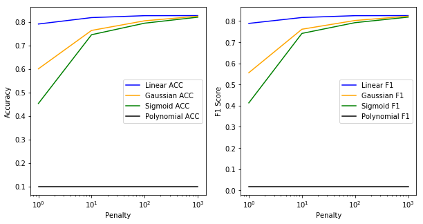

```python
# This block creates two plotting functions, that display the accuracy  and f1 score
# of each kernel on an increasing penalty parameter.

def CV_ACC_Plot():
    x = [0,1,2,3]
    plt.plot(linear_df["accuracy"], label = "Linear ACC", color = 'blue', linestyle = 'solid')
    plt.plot(rbf_df["accuracy"], label = "Gaussian ACC", color = 'orange', linestyle = 'solid')
    plt.plot(sig_df["accuracy"], label = "Sigmoid ACC", color = 'green', linestyle = 'solid')
    plt.plot(poly_df["accuracy"], label = "Polynomial ACC", color = 'black', linestyle = 'solid')
    plt.xscale('log')
    plt.legend()
    plt.xlabel('Penalty')
    plt.ylabel('Accuracy')
    plt.savefig('CV_ACC_Plot')
def CV_F1_Plot():
    x = [0,1,2,3]
    plt.plot(linear_df["f1"], label = "Linear F1", color = 'blue', linestyle = 'solid')
    plt.plot(rbf_df["f1"], label = "Gaussian F1", color = 'orange', linestyle = 'solid')
    plt.plot(sig_df["f1"], label = "Sigmoid F1", color = 'green', linestyle = 'solid')
    plt.plot(poly_df["f1"], label = "Polynomial F1", color = 'black', linestyle = 'solid')
    plt.xscale('log')
    plt.legend()
    plt.xlabel('Penalty')
    plt.ylabel('F1 Score')
    plt.savefig('CV_F1_Plot')
#CV_ACC_Plot()
#CV_F1_Plot()

# intialize figure to show
fig=plt.figure(figsize=(10,5))
columns = 2
rows = 1

# plot accuracy and F1 scores side-by-side
fig.add_subplot(1,2,1)
CV_ACC_Plot()
fig.add_subplot(1,2,2)
CV_F1_Plot()
plt.tight_layout
plt.show()
```

After k-folds CV, the best performing kernel/penalty combinations are linear, gaussian, and sigmoid, each with C = 1000. The polynomial function performs terribly; that may be an error in my implementation. The linear model performs best on all penalty values, and as the penalty for the model increases, the other kernel functions get closer to the solution for the linear optimum.

I'm going to re-fit those models on the full training set, and then make predictions on the test data for the Kaggle scorer. More on this will be in the predictive accuracy section.

```python
# initialize SVM models to train on full training data, one for each of the best
# performing combinations from CV
svc_linear = SVC(C = 1000, kernel = 'linear')
svc_gauss = SVC(C = 1000, kernel = 'rbf')
svc_sig = SVC(C = 1000, kernel = 'sigmoid')

# fit each model to the full training set
svc_linear.fit(sk_HOG_features,labels)
svc_gauss.fit(sk_HOG_features,labels)
svc_sig.fit(sk_HOG_features,labels)

# make predictions from each trained model on the test input data
y_pred_linear = svc_linear.predict(sk_HOG_features_test)
y_pred_gauss = svc_gauss.predict(sk_HOG_features_test)
y_pred_sig = svc_sig.predict(sk_HOG_features_test)
```

```python
# this block serves to further wrangle the data ouput from the CV function

# convert arrays into pandas dataframes
lin_pred = pd.DataFrame(y_pred_linear)
gauss_pred = pd.DataFrame(y_pred_gauss)
sig_pred = pd.DataFrame(y_pred_sig)

# change dataframe index and column name to match Kaggle submission format
outputs = [lin_pred,gauss_pred,sig_pred]
for prediction in outputs:
    prediction.columns = (["Category"])
    prediction.index.names = (["Id"])

# save formatted dataframes to csv files for submission
lin_pred.to_csv("y_pred_linear.csv")
gauss_pred.to_csv("y_pred_gauss.csv")
sig_pred.to_csv("y_pred_sig.csv")

# save scores from kaggle submissions
lin_pred_score = 0.82333
gauss_pred_score = 0.82000
sig_pred_score = 0.81600
```

### 4.2 CNN Hyperparameter Selection

A deep learning model is an exponentially growing pit of hyperparameters. While an SVM function has only a few knobs that can be turned to change the optimization function, deep nets have almost no limits on variables that can be changed. Particularly in CNN models with convolutions, pooling, and dropout, hyperparameter tuning is an intimidating process. Some of the highest-level hyperparameters are the batch size, number of training epochs, and the optimization method. Stochastic gradient descent is not the only option; the keras library supports multiple different optimization functions.

Because of the extremely high run-time of CNN training, I will do single-fold CV across different combinations of batch size and optimization parameter. To make a prediction on the kaggle test set, I will train the model with the best-performing hyperparameters on the full training set and fit it to the empirical test data.

```python
from keras.utils import to_categorical
from keras.models import Sequential
from keras.layers import Conv2D, MaxPooling2D
from keras.layers import Dense, Dropout, Flatten
from keras.preprocessing.image import ImageDataGenerator
from keras.preprocessing.image import img_to_array, array_to_img
from keras.applications.vgg16 import preprocess_input
from keras.applications.vgg16 import decode_predictions
from keras.applications.vgg16 import VGG16
from keras import models
from keras.models import Model
from keras import layers
from keras import optimizers
```

```python
def cnn_model(optim):
    # intialize network
    network = Sequential()

    # add convolutional layer with 3x3 window size, no extra padding
    # for each convolutional layer, I add max-pooling
    network.add(Conv2D(32, kernel_size = (3,3), activation = "relu",
                       kernel_initializer = 'glorot_normal',
                       padding = "same", input_shape = (28,28,1)))

    # add second convolutional layer with similar parameters, more convolution features
    network.add(Conv2D(64, kernel_size = (3,3), activation = "relu", padding = "same"))
    network.add(MaxPooling2D(pool_size=(2,2)))
    network.add(Dropout(0.2))

    # add final convolutional layer with 128 output features
    network.add(Conv2D(128, kernel_size = (3,3), activation = "relu", padding = "same"))
    network.add(MaxPooling2D(pool_size=(2,2)))
    network.add(Dropout(0.2))

    # flattening layer to compress convolved features
    network.add(Flatten())

    # adding layer to allow linear combination of final convolution features
    network.add(layers.Dense(units = 512, activation = "relu"))

    # add fully-connected output layer with softmax function for probability estimates
    network.add(layers.Dense(units = 10, activation = "softmax"))

    # compile network with given parameters
    network.compile(loss = "categorical_crossentropy", optimizer = optim, metrics = ['accuracy'])

    return network
```

The following two blocks have been commented-out, run, and un-commented. This is because in the markdown output, the training history of every epoch within the CNN CV was printed. Records are in the zip file.

```python
# transform input data into shapes (x) and format (y) that can be read by the CNN
cnn_x, cnn_y = images.reshape(np.shape(images)[0],28,28,1), to_categorical(labels)

# split training and validation data to monitor performance during network fit
x_train, x_val, y_train, y_val = train_test_split(cnn_x, cnn_y, test_size = 0.2)

optimizers = ["SGD","RMSprop","Adagrad","Adam"]
batch_sizes = [500,1000,2000]
#train_histories = []
for optimizer in optimizers:
    for batch_size in batch_sizes:
        network = cnn_model(optim = optimizer)
        train_cnn = network.fit(x_train, y_train, batch_size = batch_size,
                    epochs = 10, verbose = 1, validation_data = (x_val,y_val))
        train_histories.append(train_cnn.history)

#train_histories.append(train_cnn.history)
```

```python
# train network with optimal parameters on full training data,
# make predictions for kaggle test data

network = cnn_model(optim = "Adam")
x_train = images.reshape(np.shape(images)[0],28,28,1)
x_test = test_images.reshape(np.shape(test_images)[0],28,28,1)
y_train = to_categorical(labels)
train_cnn = network.fit(x_train, y_train, batch_size = 50, epochs = 10,
                      verbose = 1, validation_data = (x_val,y_val))

y_pred_kaggle = network.predict_classes(x_test)
```

```python
# this block just formats predicted data from the CNN to be submitted
cnn_y_pd2 = pd.DataFrame(y_pred_kaggle.T)
cnn_y_pd2.columns = (["Category"])
cnn_y_pd2.index.names = (["Id"])
cnn_y_pd2.to_csv("cnn_y_pd2.csv")
```

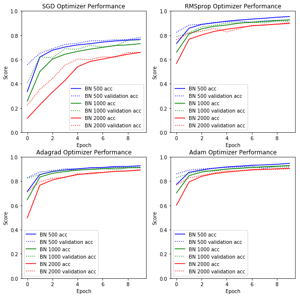

```python
# this large and unattractive block of code just visualizes the learning performance of the different
# parameter combinations. I am not going to comment through it; it's just matplotlib with subplots.
# the indices in train_histories refer to the order in which training reports were appended to the history.

def SGD_Plot():
    plt.plot(train_histories[1]['acc'], label = "BN 500 acc", color = 'blue', linestyle = 'solid')
    plt.plot(train_histories[1]['val_acc'], label = "BN 500 validation acc", color = 'blue', linestyle = 'dotted')
    plt.plot(train_histories[2]['acc'], label = "BN 1000 acc", color = 'green', linestyle = 'solid')
    plt.plot(train_histories[2]['val_acc'], label = "BN 1000 validation acc", color = 'green', linestyle = 'dotted')
    plt.plot(train_histories[3]['acc'], label = "BN 2000 acc", color = 'red', linestyle = 'solid')
    plt.plot(train_histories[3]['val_acc'], label = "BN 2000 validation acc", color = 'red', linestyle = 'dotted')
    plt.legend()
    plt.ylim(0,1)
    plt.title("SGD Optimizer Performance")
    plt.xlabel('Epoch')
    plt.ylabel('Score')
    plt.savefig('SGD_Plot')
def RMSprop_Plot():
    plt.plot(train_histories[4]['acc'], label = "BN 500 acc", color = 'blue', linestyle = 'solid')
    plt.plot(train_histories[4]['val_acc'], label = "BN 500 validation acc", color = 'blue', linestyle = 'dotted')
    plt.plot(train_histories[5]['acc'], label = "BN 1000 acc", color = 'green', linestyle = 'solid')
    plt.plot(train_histories[5]['val_acc'], label = "BN 1000 validation acc", color = 'green', linestyle = 'dotted')
    plt.plot(train_histories[6]['acc'], label = "BN 2000 acc", color = 'red', linestyle = 'solid')
    plt.plot(train_histories[6]['val_acc'], label = "BN 2000 validation acc", color = 'red', linestyle = 'dotted')
    plt.legend()
    plt.ylim(0,1)
    plt.title("RMSprop Optimizer Performance")
    plt.xlabel('Epoch')
    plt.ylabel('Score')
    plt.savefig('RMSprop_Plot')
def Adagrad_Plot():
    plt.plot(train_histories[7]['acc'], label = "BN 500 acc", color = 'blue', linestyle = 'solid')
    plt.plot(train_histories[7]['val_acc'], label = "BN 500 validation acc", color = 'blue', linestyle = 'dotted')
    plt.plot(train_histories[8]['acc'], label = "BN 1000 acc", color = 'green', linestyle = 'solid')
    plt.plot(train_histories[8]['val_acc'], label = "BN 1000 validation acc", color = 'green', linestyle = 'dotted')
    plt.plot(train_histories[9]['acc'], label = "BN 2000 acc", color = 'red', linestyle = 'solid')
    plt.plot(train_histories[9]['val_acc'], label = "BN 2000 validation acc", color = 'red', linestyle = 'dotted')
    plt.legend()
    plt.ylim(0,1)
    plt.title("Adagrad Optimizer Performance")
    plt.xlabel('Epoch')
    plt.ylabel('Score')
    plt.savefig('Adagrad_Plot')
def Adam_Plot():
    plt.plot(train_histories[10]['acc'], label = "BN 500 acc", color = 'blue', linestyle = 'solid')
    plt.plot(train_histories[10]['val_acc'], label = "BN 500 validation acc", color = 'blue', linestyle = 'dotted')
    plt.plot(train_histories[11]['acc'], label = "BN 1000 acc", color = 'green', linestyle = 'solid')
    plt.plot(train_histories[11]['val_acc'], label = "BN 1000 validation acc", color = 'green', linestyle = 'dotted')
    plt.plot(train_histories[12]['acc'], label = "BN 2000 acc", color = 'red', linestyle = 'solid')
    plt.plot(train_histories[12]['val_acc'], label = "BN 2000 validation acc", color = 'red', linestyle = 'dotted')
    plt.legend()
    plt.ylim(0,1)
    plt.title("Adam Optimizer Performance")
    plt.xlabel('Epoch')
    plt.ylabel('Score')
    plt.savefig('Adam_Plot')

# intialize figure to show
fig=plt.figure(figsize=(10,10))
columns = 2
rows = 2

# plot train and validation accuracy by batch size each optimizer
fig.add_subplot(2,2,1)
SGD_Plot()
fig.add_subplot(2,2,2)
RMSprop_Plot()
fig.add_subplot(2,2,3)
Adagrad_Plot()
fig.add_subplot(2,2,4)
Adam_Plot()
plt.tight_layout
plt.show()
```

### 4.2 Hyperparameter selection: CNN

From the plots, it is apparent that the Adam optimizer performs best with this data. Stochastic Gradient Descent, while a staple of neural network training, performs the most poorly of the optimizers tested. From the results of this process, I will choose Adam with low batch-size to train for the competition.

## 5. Data Splits

For each iteration of hyperparameter cross-validation in the SVM model, I am using the stratified k-folds function from sklearn with 5 folds. This helps for performing nested cross-validation, as without shuffling and with multi-class stratification to balance the class allocation among sets of training and validation data, there isn't overlap across the fold partitions. As explained in the hyperparameter selection section, I took average performance over k-folds CV to determine which hyperparameter combination performed the best in generalization and thus had the lowest risk of overfitting the test data.

For the convolutional neural network, doing nested CV wasn't really an option computationally. I used a uniform train/validation split for the keras training module, and evaluated fits on that. By seeing where the test accuracy and validation accuracy diverged, I could determine where to stop the model training to avoid overfitting.

## 6. Errors and Mistakes

In the model building process for SVM, I wrote up a HOG feature generator from scratch. This took a considerable amount of time for me, and I thought it was a necessary step. It isn't terribly slow, and it was certainly good practice, but I found out later that the python package skimage has built-in HOG feature creators. Because the implementation is so simple through skimage, I ended up using that for later iterations of training. I left in my original code for posterity's sake, but its end purpose is really just as a learning experience.

A few times while I was exploring training options and comparing predicitive accuracy without full cross-validation, I let my SVM train and make predictions without assigning variables to the classifier and predictor output; this was also a huge waste of time and a source of frustration with myself. I also struggled for a couple of hours with a bug that was due to my inputs not being the correct array format.

After finding what I thought were optimal parameters for my CNN, I made the mistake of doing grad-student-descent: I assumed that since smaller batch size had been better for generalization, making the batch size even smaller and training on the full set would get me the best kaggle test accuracy; this was not true. The time spend training an overfitting model could have been used to optimize parameters in the network structure.

Finally, the time and computational power necessary to finely tune CNN hyperparameters sets performance standards beyond what I could expect to accomplish with only one computer; grid search would have been a great thing to implement, but I didn't have the resources to do it well.

The hardest part, and this is a good thing, is making the data-science process into something that is easily interpretable to others who are looking at my work. Jupyter makes this relatively easy, but I have to keep a much cleaner workspace and use more comments than I'm used to.

## 7. Predictive Accuracy

The first submission to the kaggle competition was from a default SVM; linear kernel with penalty of 1; I was excited that the HOG feature generator had worked, and immediately made a prediction set on the test images. After doing CV on the SVM model, I submitted 3 test predictions for the three best hyperparameter combinations: ([linear, C = 1000],[gaussian, C = 1000],[sigmoid, C = 1000]. These scored 82.33%, 82.00%, and 81.60% respectively on the kaggle testing sample.

The best illustration of predictive accuracy of my convolutional neural nets is in the hyperparameter tuning above; because I did a single split for cross-validation, the validation performance of the different CNN models is a good measure of predictive accuracy. For the cnn submissions, Adam was my best optimizer, and 100 was my best batch size.

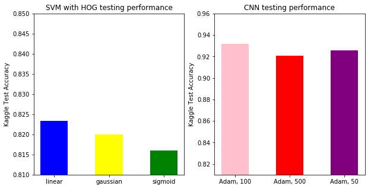

```python
# one last big nasty plot block for predictive accuracy!

def svm_test_plot():
    plt.bar([1,2,3], [lin_pred_score, gauss_pred_score, sig_pred_score],
            width=0.5, bottom=0.0, align='center', tick_label = ["linear","gaussian","sigmoid"],
            color = ['blue','yellow','green'])
    plt.ylim(0.81,0.85)
    plt.ylabel("Kaggle Test Accuracy")
    plt.title("SVM with HOG testing performance")
def cnn_test_plot():
    plt.bar([1,2,3], [0.932, 0.92066, 0.926],
            width=0.5, bottom=0.0, align='center', tick_label = ["Adam, 100","Adam, 500","Adam, 50"],
            color = ['pink','red','purple'])
    plt.ylim(0.81, 0.96)
    plt.ylabel("Kaggle Test Accuracy")
    plt.title("CNN testing performance")

fig=plt.figure(figsize=(10,5))

fig.add_subplot(1,2,1)
svm_test_plot()
fig.add_subplot(1,2,2)
cnn_test_plot()
fig.show()
```